# chapter3

I also created a categorical variable of the crime rate in the Boston datasetand dropped the old crime rate variable from the dataset. This is necessary for the clustering we will do later on.

Moreover, I finally divided the dataset to train and test sets. Now 80% of the data belongs to the train set and 20% to the test set.

Now I will fit the Linear Discriminant Analysis to the train data, by using `crime` as a target variable and all other variables as predictors.

```
## Call:
## lda(crime ~ ., data = train)
##
## Prior probabilities of groups:
##       low   med_low  med_high      high
## 0.2475248 0.2376238 0.2475248 0.2673267
##
## Group means:
##                   zn      indus        chas        nox         rm
## low       1.00102522 -0.9048191 -0.11484506 -0.8792553  0.4405609
## med_low  -0.09978273 -0.3096305 -0.10828322 -0.5424925 -0.1088179
## med_high -0.37490209  0.1736093  0.23949396  0.4261817  0.1336796
## high     -0.48724019  1.0169921 -0.05360128  1.0783189 -0.4575422
##                 age        dis        rad        tax     ptratio
## low      -0.8632996  0.8525349 -0.6648943 -0.7427869 -0.41873275
## med_low  -0.2818685  0.2985681 -0.5404292 -0.4523464 -0.03816121
## med_high  0.4361490 -0.3757458 -0.3950046 -0.3086985 -0.39009462
## high      0.8232721 -0.8586789  1.6393984  1.5149640  0.78225547
##               black       lstat         medv
## low       0.3773199 -0.76247253  0.535298245
## med_low   0.3098971 -0.15204624  0.005040754
## med_high  0.0659256 -0.03018644  0.169313477
## high     -0.6719005  0.95278289 -0.704874737
##
## Coefficients of linear discriminants:
##                   LD1          LD2         LD3
## zn       0.0647479787  0.763012214 -0.93514036
## indus    0.0007651644 -0.284260016  0.06861527
## chas    -0.1182281167 -0.023671603 -0.03967638
## nox      0.4068625816 -0.684893222 -1.25870733
## rm      -0.0857420657 -0.067704535 -0.18622631
## age      0.3233112626 -0.442590021 -0.09793313
## dis     -0.0231613620 -0.395609818  0.12604542
## rad      2.9716306691  0.855926086 -0.40574268
## tax      0.0232313545  0.023672278  0.88170654
## ptratio  0.1008037274  0.113110123 -0.15366545
## black   -0.0943264644  0.002298664  0.11015406
## lstat    0.2114673941 -0.109778504  0.37006469
## medv     0.1762177965 -0.277155226 -0.09806397
##
## Proportion of trace:
##    LD1    LD2    LD3
## 0.9446 0.0422 0.0132
```

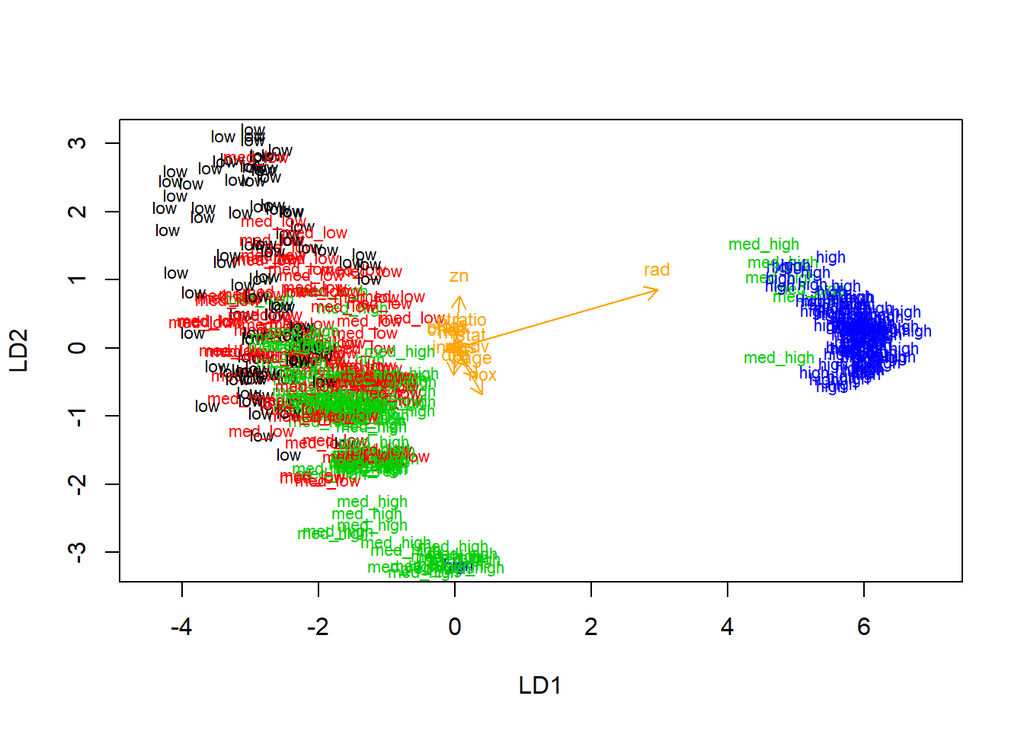

Above you see an LDI biplot with an arrow function. We can interpret from this picture the strenght of specific variables have in clustering the data (and to which direction). For example, `rad` seems to cluster the data into the high-category.

Next I will predict test data with trained model.

```
##           predicted
## correct    low med_low med_high high
##   low       15      11        1    0
##   med_low    8      20        2    0
##   med_high   1       9       16    0
##   high       0       0        0   19
```

Next, I will move on to k-means clustering. Let’s reload the data and standardize it (much like above):

```
##       crim                 zn               indus
##  Min.   :-0.419367   Min.   :-0.48724   Min.   :-1.5563
##  1st Qu.:-0.410563   1st Qu.:-0.48724   1st Qu.:-0.8668
##  Median :-0.390280   Median :-0.48724   Median :-0.2109
##  Mean   : 0.000000   Mean   : 0.00000   Mean   : 0.0000
##  3rd Qu.: 0.007389   3rd Qu.: 0.04872   3rd Qu.: 1.0150
##  Max.   : 9.924110   Max.   : 3.80047   Max.   : 2.4202
##       chas              nox                rm               age
##  Min.   :-0.2723   Min.   :-1.4644   Min.   :-3.8764   Min.   :-2.3331
##  1st Qu.:-0.2723   1st Qu.:-0.9121   1st Qu.:-0.5681   1st Qu.:-0.8366
##  Median :-0.2723   Median :-0.1441   Median :-0.1084   Median : 0.3171
##  Mean   : 0.0000   Mean   : 0.0000   Mean   : 0.0000   Mean   : 0.0000
##  3rd Qu.:-0.2723   3rd Qu.: 0.5981   3rd Qu.: 0.4823   3rd Qu.: 0.9059
##  Max.   : 3.6648   Max.   : 2.7296   Max.   : 3.5515   Max.   : 1.1164
##       dis               rad               tax             ptratio
##  Min.   :-1.2658   Min.   :-0.9819   Min.   :-1.3127   Min.   :-2.7047
##  1st Qu.:-0.8049   1st Qu.:-0.6373   1st Qu.:-0.7668   1st Qu.:-0.4876
##  Median :-0.2790   Median :-0.5225   Median :-0.4642   Median : 0.2746
##  Mean   : 0.0000   Mean   : 0.0000   Mean   : 0.0000   Mean   : 0.0000
##  3rd Qu.: 0.6617   3rd Qu.: 1.6596   3rd Qu.: 1.5294   3rd Qu.: 0.8058
##  Max.   : 3.9566   Max.   : 1.6596   Max.   : 1.7964   Max.   : 1.6372
##      black             lstat              medv
##  Min.   :-3.9033   Min.   :-1.5296   Min.   :-1.9063
##  1st Qu.: 0.2049   1st Qu.:-0.7986   1st Qu.:-0.5989
##  Median : 0.3808   Median :-0.1811   Median :-0.1449
##  Mean   : 0.0000   Mean   : 0.0000   Mean   : 0.0000
##  3rd Qu.: 0.4332   3rd Qu.: 0.6024   3rd Qu.: 0.2683
##  Max.   : 0.4406   Max.   : 3.5453   Max.   : 2.9865
```

```
## [1] "matrix"
```

Now count euclidean and manhattan distances.

```
##    Min. 1st Qu.  Median    Mean 3rd Qu.    Max.
##  0.1343  3.4625  4.8241  4.9111  6.1863 14.3970
```

```
##    Min. 1st Qu.  Median    Mean 3rd Qu.    Max.
##  0.2662  8.4832 12.6090 13.5488 17.7568 48.8618
```

There’s nothing surprising here: manhattan distances seem longer, but the in fact the relations between euclidean and manhattan distances are more or less similar.